# RIC vs MAC Disease Free Survival (DFS) Meta Analysis

Kushal Kumar Dey

Wednesday, May 20, 2015

[output not shown]

```
##        trials RIC_events RIC_non_events MAC_events MAC_non_events weight
## 1  Marks 2010         32             61        600            828  0.274
## 2  Mohty 2010         48             79        162            287  0.266
## 3    Eom 2013         34             26         54             66  0.134
## 4 Tanaka 2013         72            134        122            247  0.326
```

Meta analysis on the above data is performed on two effects

- Odds Ratio (OR)
- Relative Risk (RR)

## Odds Ratio (OR) analysis

The Odds ratio and its variance are given by

```
##                Y          V
## [1,] -0.32305446 0.05097678
## [2,]  0.07363904 0.04583724
## [3,]  0.46893468 0.10491034
## [4,]  0.08419361 0.03774502
```

```
##
## Fixed-Effects Model (k = 4)
##
##   logLik  deviance       AIC       BIC      AICc
##  -0.0801    4.3994    2.1603    1.5466    4.1603
##
## Test for Heterogeneity:
## Q(df = 3) = 4.3994, p-val = 0.2214
##
## Model Results:
##
## estimate       se     zval     pval    ci.lb    ci.ub
##   0.0254   0.1136   0.2238   0.8229  -0.1973   0.2481
##
## ---
## Signif. codes:  0 '***' 0.001 '**' 0.01 '*' 0.05 '.' 0.1 ' ' 1
```

```
## The confidence interval for the Odds Ratio is given by : CI.lb= 0.8209711 Est= 1.025755 CI.ub= 1.281621
```

```
##       weights
## [1,] 25.32549
## [2,] 28.16514
## [3,] 12.30586
## [4,] 34.20351
```

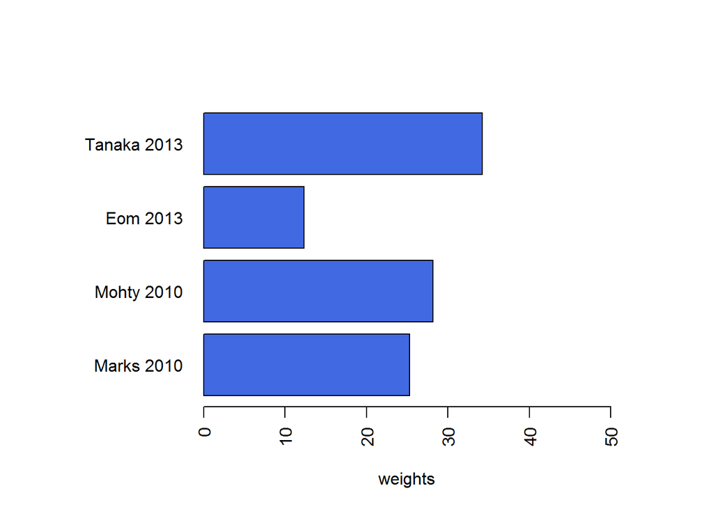

```
##
## Random-Effects Model (k = 4; tau^2 estimator: DL)
##
##   logLik  deviance       AIC       BIC      AICc
##  -0.2563    4.7518    4.5127    3.2853   16.5127
##
## tau^2 (estimated amount of total heterogeneity): 0.0249 (SE = 0.0643)
## tau (square root of estimated tau^2 value):      0.1579
## I^2 (total heterogeneity / total variability):   31.81%
## H^2 (total variability / sampling variability):  1.47
##
## Test for Heterogeneity:
## Q(df = 3) = 4.3994, p-val = 0.2214
##
## Model Results:
##
## estimate       se     zval     pval    ci.lb    ci.ub
##   0.0341   0.1401   0.2437   0.8075  -0.2404   0.3087
##
## ---
## Signif. codes:  0 '***' 0.001 '**' 0.01 '*' 0.05 '.' 0.1 ' ' 1
```

```
##       weights
## [1,] 25.32549
## [2,] 28.16514
## [3,] 12.30586
## [4,] 34.20351
```

```
##
## Random-Effects Model (k = 4; tau^2 estimator: REML)
##
##   logLik  deviance       AIC       BIC      AICc
##  -0.6022    1.2044    5.2044    3.4016   17.2044
##
## tau^2 (estimated amount of total heterogeneity): 0.0161 (SE = 0.0561)
## tau (square root of estimated tau^2 value):      0.1270
## I^2 (total heterogeneity / total variability):   23.17%
## H^2 (total variability / sampling variability):  1.30
##
## Test for Heterogeneity:
## Q(df = 3) = 4.3994, p-val = 0.2214
##
## Model Results:
##
## estimate       se     zval     pval    ci.lb    ci.ub
##   0.0313   0.1315   0.2381   0.8118  -0.2264   0.2890
##
## ---
## Signif. codes:  0 '***' 0.001 '**' 0.01 '*' 0.05 '.' 0.1 ' ' 1
```

```
##       weights
## [1,] 25.32549
## [2,] 28.16514
## [3,] 12.30586
## [4,] 34.20351
```

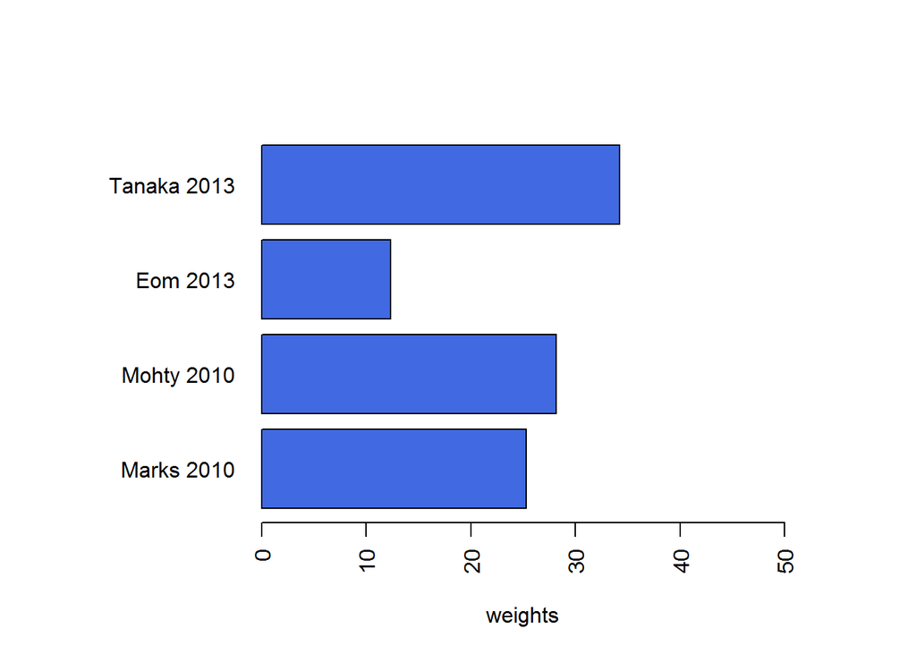

Now we focus on the tests of heterogeneity, the values f $Q$ have been reported above for both the Random effects methods and the Fixed effect method,however $Q$ statistic in this case is not recommended as a measure of heterogeneity bacause the number of trials is small, only 4, and therefore the Q test will have lower power. So, we consider other measures of heterogeneity

The heterogeneity measures for Fixed effect method

```
##
##        estimate  ci.lb   ci.ub
## tau^2        NA 0.0000  1.3765
## tau          NA 0.0000  1.1732
## I^2(%)       NA 0.0000 96.2611
## H^2          NA 1.0000 26.7457
```

The heterogeneity measure for the Random effect DL method

```
##
##        estimate  ci.lb   ci.ub
## tau^2    0.0249 0.0000  1.3765
## tau      0.1579 0.0000  1.1732
## I^2(%)  31.8086 0.0000 96.2611
## H^2      1.4665 1.0000 26.7457
```

The heterogeneity measures for the Random effect REML method

```
##
##        estimate  ci.lb   ci.ub
## tau^2    0.0161 0.0000  1.3765
## tau      0.1270 0.0000  1.1732
## I^2(%)  23.1725 0.0000 96.2611
## H^2      1.3016 1.0000 26.7457
```

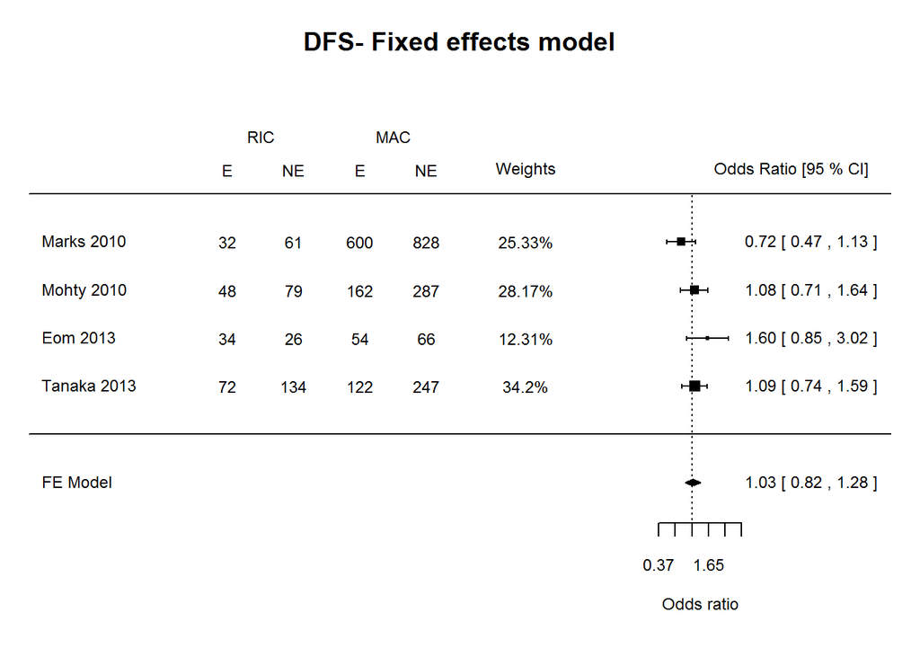

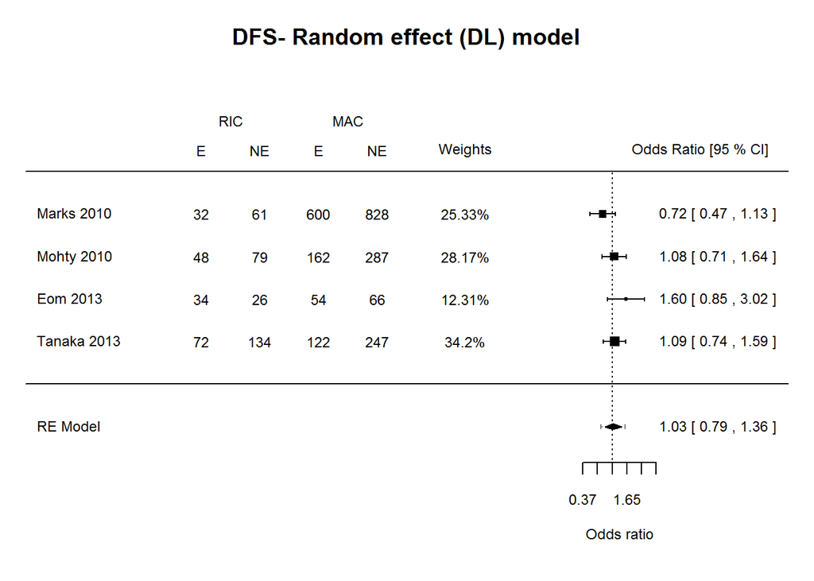

[figure not shown]

We now consider how sensitive the method is to the removal of one of the trials. For this, we only apply the leave one out sensitivity analysis on the REML random effects method.

```
##   estimate     se    zval   pval   ci.lb  ci.ub      Q     Qp   tau2
## 1   0.1436 0.1315  1.0923 0.2747 -0.1141 0.4013 1.2092 0.5463 0.0000
## 2   0.0338 0.2064  0.1636 0.8701 -0.3708 0.4383 4.3288 0.1148 0.0689
## 3  -0.0380 0.1255 -0.3024 0.7623 -0.2840 0.2080 2.2614 0.3228 0.0031
## 4   0.0288 0.2110  0.1366 0.8914 -0.3847 0.4423 4.2603 0.1188 0.0709
##        I2     H2
## 1  0.0000 1.0000
## 2 54.2945 2.1879
## 3  6.4139 1.0685
## 4 53.3605 2.1441
```

Note that the $Qp$ does not change drastically if we leave one of the trials out. This means that our process is not very sensitive to any given trial.

We now look at the Funnel plot in order to determine the Publicattion Bias

First we consider the Publication Bias for the REML Random Effects model. That for the other models is also same

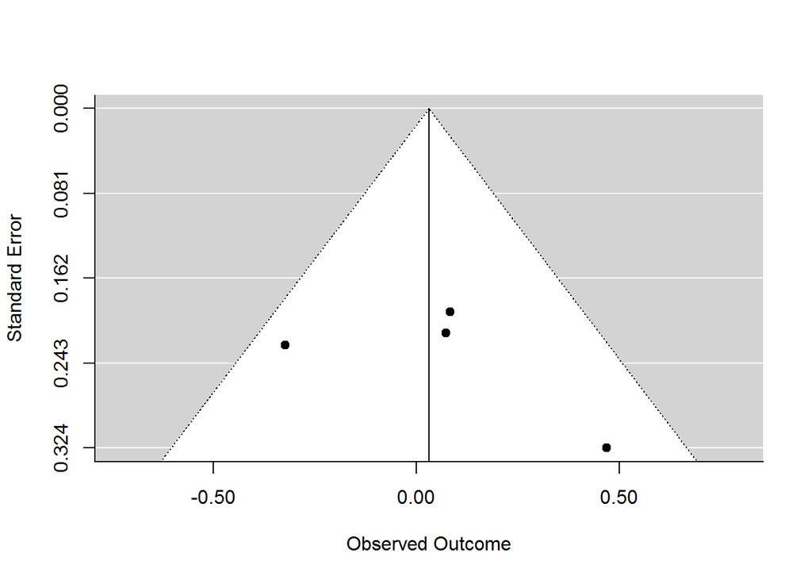

```
##
## Estimated number of missing studies on the left side: 1 (SE = 1.5779)
##
## Random-Effects Model (k = 5; tau^2 estimator: REML)
##
## tau^2 (estimated amount of total heterogeneity): 0.0387 (SE = 0.0701)
## tau (square root of estimated tau^2 value):      0.1968
## I^2 (total heterogeneity / total variability):   39.33%
## H^2 (total variability / sampling variability):  1.65
##
## Test for Heterogeneity:
## Q(df = 4) = 7.1597, p-val = 0.1277
##
## Model Results:
##
## estimate       se     zval     pval    ci.lb    ci.ub
##  -0.0432   0.1415  -0.3053   0.7602  -0.3204   0.2341
##
## ---
## Signif. codes:  0 '***' 0.001 '**' 0.01 '*' 0.05 '.' 0.1 ' ' 1
```

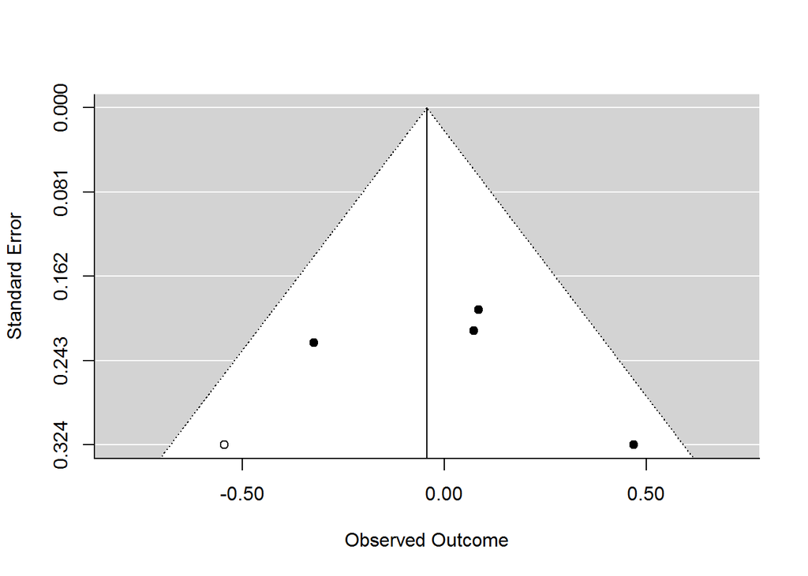

```
##
## Fail-safe N Calculation Using the Rosenthal Approach
##
## Observed Significance Level: 0.3456
## Target Significance Level:   0.05
##
## Fail-safe N: 0
```

We test for the Publication Bias using the Begg and Egger’s test, which are the Regression and Rank tests for funnel plot asymmetry.

```
##
## Regression Test for Funnel Plot Asymmetry
##
## model:     mixed-effects meta-regression model
## predictor: standard error
##
## test for funnel plot asymmetry: z = 0.9676, p = 0.3333
```

```
##
## Rank Correlation Test for Funnel Plot Asymmetry
##
## Kendall's tau = 0.0000, p = 1.0000
```

## Relative Risk (RR) analysis

The relative risk and its variance are given by

```
##                Y          V
## [1,] -0.19976310 0.02146370
## [2,]  0.04644048 0.01690499
## [3,]  0.23052366 0.02293028
## [4,]  0.05556555 0.01452121
```

```
##
## Fixed-Effects Model (k = 4)
##
##   logLik  deviance       AIC       BIC      AICc
##   2.1530    4.2714   -2.3061   -2.9198   -0.3061
##
## Test for Heterogeneity:
## Q(df = 3) = 4.2714, p-val = 0.2336
##
## Model Results:
##
## estimate       se     zval     pval    ci.lb    ci.ub
##   0.0335   0.0677   0.4955   0.6202  -0.0991   0.1662
##
## ---
## Signif. codes:  0 '***' 0.001 '**' 0.01 '*' 0.05 '.' 0.1 ' ' 1
```

```
## The confidence interval for the Relative  Risk is given by : CI.lb= 0.9056204 Est= 1.034113 CI.ub= 1.180836
```

```
##       weights
## [1,] 21.35018
## [2,] 27.10762
## [3,] 19.98466
## [4,] 31.55754
```

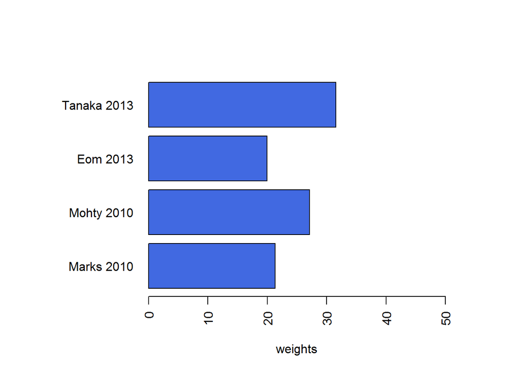

```
##
## Random-Effects Model (k = 4; tau^2 estimator: DL)
##
##   logLik  deviance       AIC       BIC      AICc
##   2.0058    4.5659   -0.0116   -1.2390   11.9884
##
## tau^2 (estimated amount of total heterogeneity): 0.0079 (SE = 0.0216)
## tau (square root of estimated tau^2 value):      0.0886
## I^2 (total heterogeneity / total variability):   29.77%
## H^2 (total variability / sampling variability):  1.42
##
## Test for Heterogeneity:
## Q(df = 3) = 4.2714, p-val = 0.2336
##
## Model Results:
##
## estimate       se     zval     pval    ci.lb    ci.ub
##   0.0332   0.0812   0.4087   0.6828  -0.1260   0.1923
##
## ---
## Signif. codes:  0 '***' 0.001 '**' 0.01 '*' 0.05 '.' 0.1 ' ' 1
```

```
##       weights
## [1,] 21.35018
## [2,] 27.10762
## [3,] 19.98466
## [4,] 31.55754
```

```
##
## Random-Effects Model (k = 4; tau^2 estimator: REML)
##
##   logLik  deviance       AIC       BIC      AICc
##   1.1117   -2.2235    1.7765   -0.0263   13.7765
##
## tau^2 (estimated amount of total heterogeneity): 0.0055 (SE = 0.0196)
## tau (square root of estimated tau^2 value):      0.0744
## I^2 (total heterogeneity / total variability):   22.99%
## H^2 (total variability / sampling variability):  1.30
##
## Test for Heterogeneity:
## Q(df = 3) = 4.2714, p-val = 0.2336
##
## Model Results:
##
## estimate       se     zval     pval    ci.lb    ci.ub
##   0.0333   0.0775   0.4292   0.6678  -0.1186   0.1851
##
## ---
## Signif. codes:  0 '***' 0.001 '**' 0.01 '*' 0.05 '.' 0.1 ' ' 1
```

```
##       weights
## [1,] 21.35018
## [2,] 27.10762
## [3,] 19.98466
## [4,] 31.55754
```

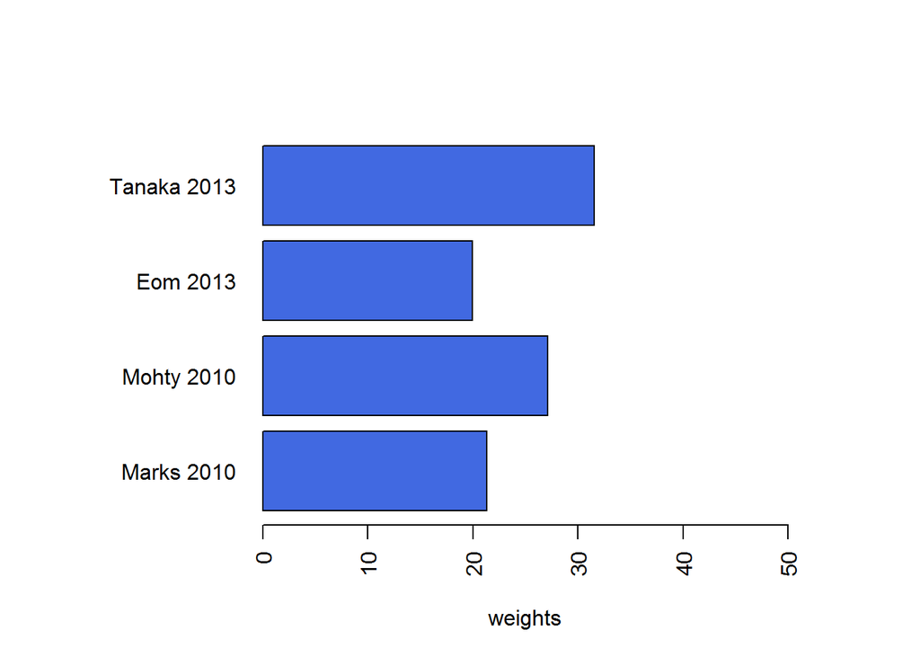

The heterogeneity measures for Fixed effect method

```
##
##        estimate  ci.lb   ci.ub
## tau^2        NA 0.0000  0.4130
## tau          NA 0.0000  0.6427
## I^2(%)       NA 0.0000 95.7033
## H^2          NA 1.0000 23.2738
```

The heterogeneity measure for the Random effect DL method

```
##
##        estimate  ci.lb   ci.ub
## tau^2    0.0079 0.0000  0.4130
## tau      0.0886 0.0000  0.6427
## I^2(%)  29.7650 0.0000 95.7033
## H^2      1.4238 1.0000 23.2738
```

The heterogeneity measures for the Random effect REML method

```
##
##        estimate  ci.lb   ci.ub
## tau^2    0.0055 0.0000  0.4130
## tau      0.0744 0.0000  0.6427
## I^2(%)  22.9874 0.0000 95.7033
## H^2      1.2985 1.0000 23.2738
```

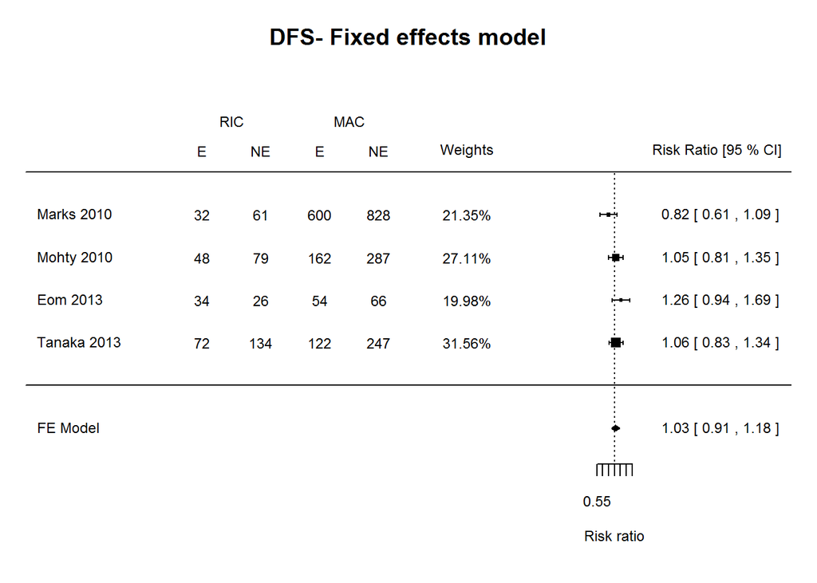

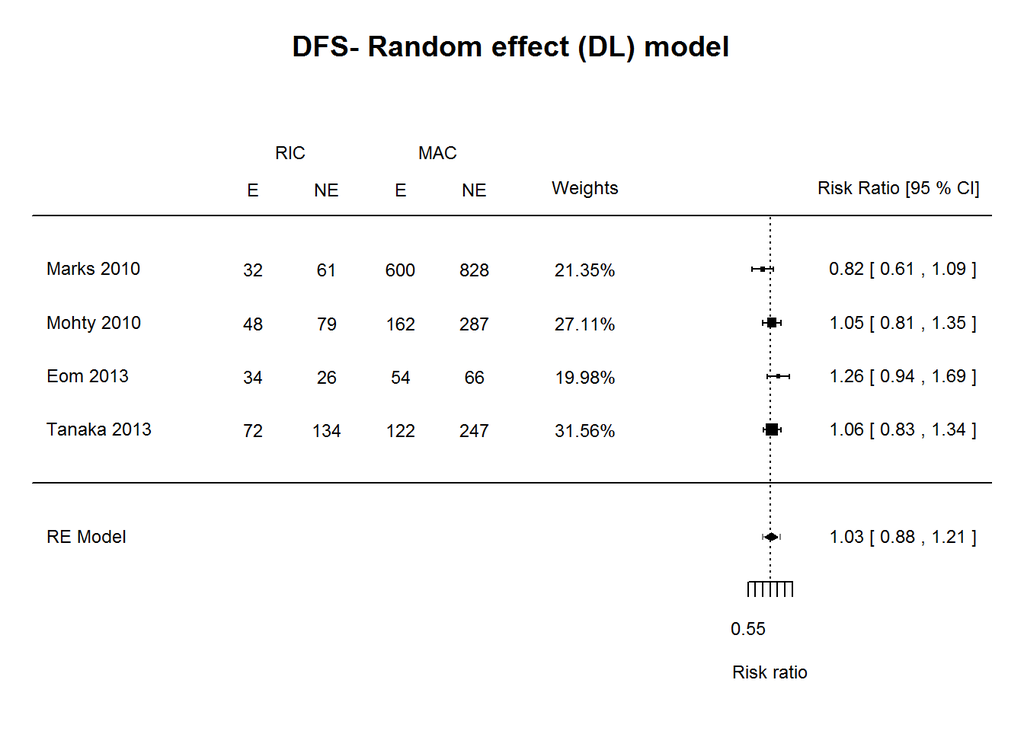

[figure not shown]

We now consider how sensitive the method is to the removal of one of the trials. For this, we only apply the leave one out sensitivity analysis on the REML random effects method.

```
##   estimate     se    zval   pval   ci.lb  ci.ub      Q     Qp   tau2
## 1   0.0969 0.0763  1.2692 0.2044 -0.0527 0.2465 1.0470 0.5925 0.0000
## 2   0.0283 0.1175  0.2409 0.8097 -0.2020 0.2586 4.2579 0.1190 0.0221
## 3  -0.0157 0.0757 -0.2069 0.8361 -0.1640 0.1327 2.1566 0.3402 0.0000
## 4   0.0244 0.1197  0.2036 0.8387 -0.2103 0.2590 4.2226 0.1211 0.0227
##        I2     H2
## 1  0.0000 1.0000
## 2 53.4162 2.1467
## 3  0.0010 1.0000
## 4 52.8561 2.1212
```

Note that the $Qp$ does not change drastically if we leave one of the trials out. This means that our process is not very sensitive to any given trial.

We now look at the Funnel plot in order to determine the Publicattion Bias

First we consider the Publication Bias for the REML Random Effects model. That for the other models is also same

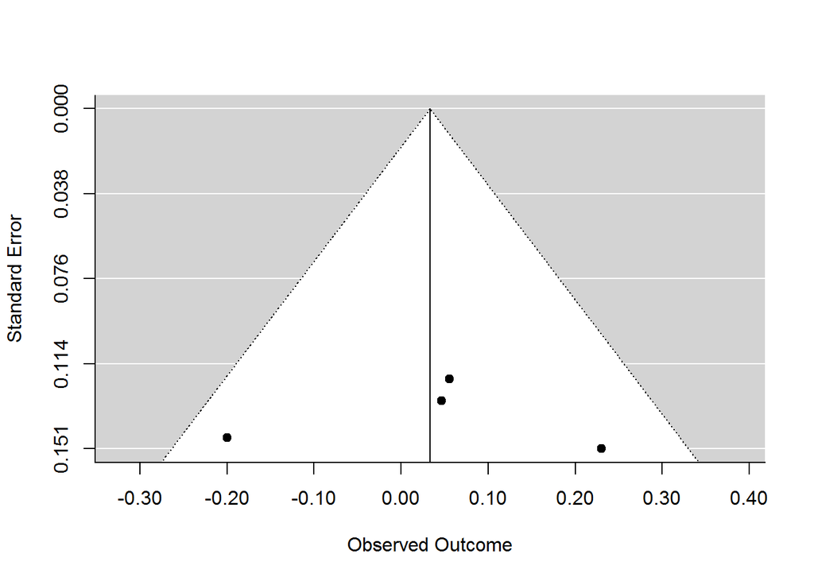

```
##
## Estimated number of missing studies on the right side: 0 (SE = 1.3802)
##
## Random-Effects Model (k = 4; tau^2 estimator: REML)
##
## tau^2 (estimated amount of total heterogeneity): 0.0055 (SE = 0.0196)
## tau (square root of estimated tau^2 value):      0.0744
## I^2 (total heterogeneity / total variability):   22.99%
## H^2 (total variability / sampling variability):  1.30
##
## Test for Heterogeneity:
## Q(df = 3) = 4.2714, p-val = 0.2336
##
## Model Results:
##
## estimate       se     zval     pval    ci.lb    ci.ub
##   0.0333   0.0775   0.4292   0.6678  -0.1186   0.1851
##
## ---
## Signif. codes:  0 '***' 0.001 '**' 0.01 '*' 0.05 '.' 0.1 ' ' 1
```

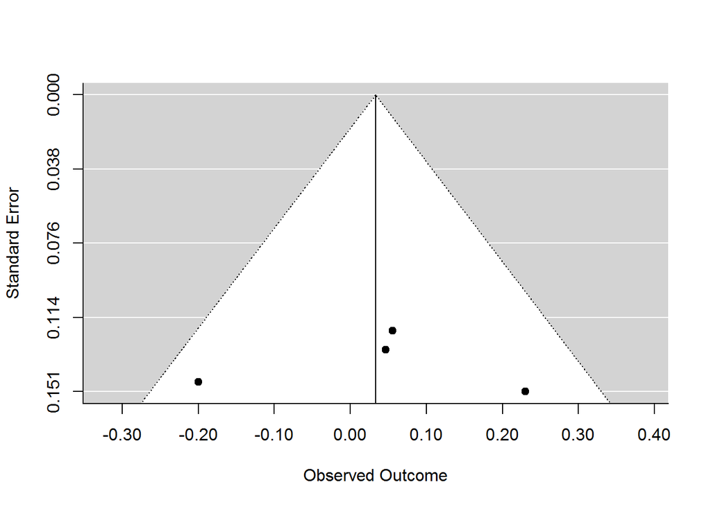

```
##
## Fail-safe N Calculation Using the Rosenthal Approach
##
## Observed Significance Level: 0.3126
## Target Significance Level:   0.05
##
## Fail-safe N: 0
```

We test for the Publication Bias using the Begg and Egger’s test

```
##
## Regression Test for Funnel Plot Asymmetry
##
## model:     mixed-effects meta-regression model
## predictor: standard error
##
## test for funnel plot asymmetry: z = -0.0008, p = 0.9993
```

```
##
## Rank Correlation Test for Funnel Plot Asymmetry
##
## Kendall's tau = 0.0000, p = 1.0000
```